# Three-Slide KT Story

Jasmine Li

## Question And Audience

**Audience:** Our target audience is public health students and health education professionals. We aim to help them understand differences in waist circumference across education levels among US adults through clear visualizations.

**Question:** How does mean waist circumference differ across education levels among adults aged 20–80?

**Why it matters:** This study matters because differences in mean waist circumference across education levels may reveal socioeconomic inequalities in health and help identify groups that could benefit from more accessible health education and preventive services.

## Evidence

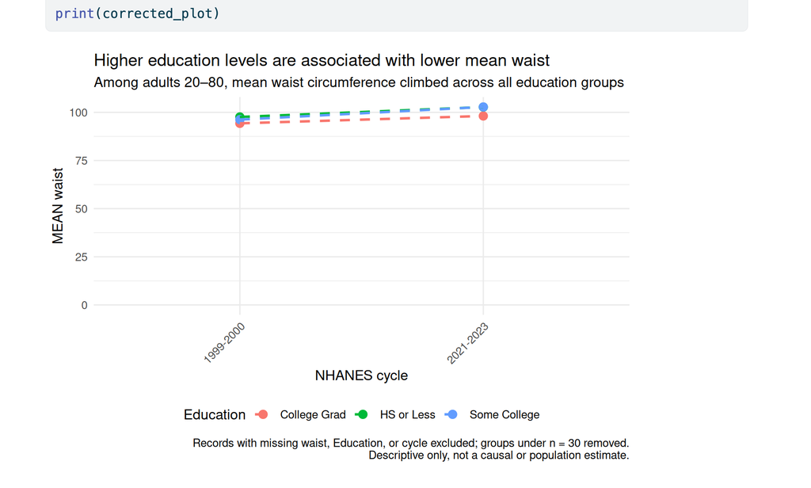

Mean waist circumference by education level

Source note: CDC/NCHS NHANES public-use data are the source for the NHANES classroom example (Centers for Disease Control and Prevention, National Center for Health Statistics 2026).

## Limitation And Next Step

**Limitation:** since it’s an oservational study which may include confounding variables, it cannot prove that the education level causes the decrease of waist circumference.

**Next step:** We could calculate the difference in mean waist circumference between the College Grad and Some College groups for each survey cycle. Collecting more detailed data, such as monthly measurements, would allow us to plot trends over time.

**AI-use note:** 1. I asked ai to help me rephrase the word in limitation part 2. I asked ai to plot the graph using R code, and use the example in assinment 7 as reference, providing the dataset in data file nhanes 3. I aksed ai to help me edit the relative path in evidence part to make sure it fits the markdown file

Centers for Disease Control and Prevention, National Center for Health Statistics. 2026. *National Health and Nutrition Examination Survey*. https://wwwn.cdc.gov/nchs/nhanes/.